# Web Applications

## A Common Situation

[figure not shown]

## Lesson Learned

Before development, understand:

- **What** the user wants
- **What** the user needs
- **How** they will use the app

Build for the user’s context, not just the developer’s.

## How Applications Are Installed

[output not shown]

If an app needs to run on all 4 platforms, it needs to be written 4 times.

## Distribution Question

After the app is done, how do you put it on the platform so the user can download it?

[figure not shown]

## From App to Download

1. Make the app
2. Create a Google / Apple developer account
3. Pay the fee: **USD 25** for Google, **USD 99** for Apple
4. Provide real name, government ID, and address verification

## Posible Public Info Disclosure

[output not shown]

## What If We Bypass the App Stores?

What if we send the app package directly to the user instead?

[figure not shown]

## Android Sideloading Is Getting Harder

Starting **September 2026**, Google requires all Android app developers to:

- Register and verify identity
- Submit government ID
- Pay a fee

Which include sideloaded apps

## Desktop Apps Also Face Trust Warnings

Unverified `.exe` and `.dmg` files trigger security warnings:

[output not shown]

## Removing the Warnings

To avoid security warnings, you must sign your app:

| Platform | Cost (annual) | Verification |
| --- | --- | --- |
| macOS (`.dmg`) | **USD 99** to Apple | Government ID required |
| Windows (`.exe`) | **USD 280–650** to a Certificate Authority | ID / notary / business verification |

**Individuals:** photo ID, selfie, credit-card name match

**Businesses:** legal registration, physical address, verification phone call

## The Big Questions

Can we publish it **without** paying a middleman?

Can we publish it **without** handing our private information to a gatekeeper?

## The Answer: Web Apps

**Web apps** run in the browser on any device — no store required.

Examples:

- [HK Taxi Fee Calculator](https://hkcoding.com/en/taxi-fee-calc/) — estimate taxi fares
- [HK Bus App](https://hkbus.app/) — live public transport arrival times
- [Photopea](https://www.photopea.com/) — full online image editor

## A Web App Is Just a URL

Instead of downloading a file, users open a web app with a link:

```
https://www........com
```

No install. No store. No package file.

## Easy Distribution: QR Code

A web app can be shared anywhere.

[figure not shown]

## Easy Distribution: Social Bio Link

[figure not shown]

## Easy Distribution: Direct Message

[figure not shown]

## Traditional App: Many Drop-Off Points

Every step loses users.

[figure not shown]

## Web App: Fewer Steps, Less Friction

The website is the app.

[figure not shown]

## Location Matters

Where you place your app affects how many people use it.

The further people must walk, the fewer will come.

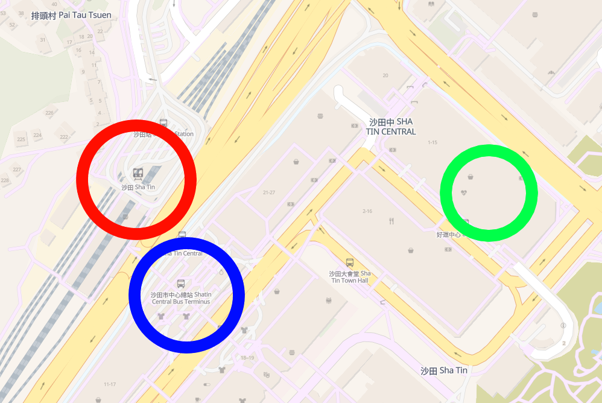

- Train station
- New Town Plaza
- Lucky Plaza

## Foot Traffic Comparison

More distance = fewer visitors.

[output not shown]

## The Same Applies to Apps

**More steps to open and use an app means fewer users.**

Web apps remove the download, install, and trust-warning steps.

## What If There Is No Internet?

A basic web app needs a connection to the server.

[figure not shown]

## Progressive Web Apps (PWA)

PWAs can store pages on the device and work offline.

[figure not shown]

## Try It Yourself: Dino PWA

1. Open Chrome and visit:

   `https://r121p.github.io/static_resources/dino_pwa/`
2. Install the PWA when prompted:

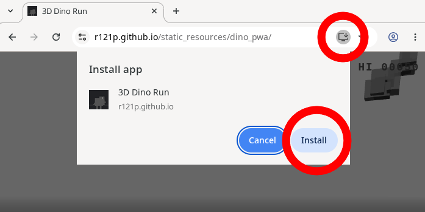

## Test Offline

3. Disconnect from the internet and open the same URL.
4. Try rebooting your computer without internet — the app still works.

## When Native Apps Still Win

Web apps are not perfect. Traditional apps are still better for:

- Heavy graphics or games
- Deep hardware access (camera, sensors, Bluetooth)
- Always-offline use without extra setup
- Platform-specific features

## Recap

- Know your users before you build.
- Native apps face platform fees, verification, and trust warnings.
- Web apps run anywhere with just a URL — less friction, wider reach.
- PWAs can even work offline.

**Choose the right tool for the job.**